# Machine Learning - Final Project

Renato Oliveira Fraga

9/30/2017

## Abstract

Using devices such as Jawbone Up, Nike FuelBand, and Fitbit it is now possible to collect a large amount of data about personal activity relatively inexpensively. These type of devices are part of the quantified self movement – a group of enthusiasts who take measurements about themselves regularly to improve their health, to find patterns in their behavior, or because they are tech geeks. One thing that people regularly do is quantify how much of a particular activity they do, but they rarely quantify how well they do it. In this project, your goal will be to use data from accelerometers on the belt, forearm, arm, and dumbell of 6 participants. They were asked to perform barbell lifts correctly and incorrectly in 5 different ways. More information is available from the website here: http://web.archive.org/web/20161224072740/http:/groupware.les.inf.puc-rio.br/har (see the section on the Weight Lifting Exercise Dataset).

### Loading Libraries

```r
library(caret)
```

```r
library(knitr)
library(ggplot2)
library(gbm)
```

## Data

The training data for this project are available here:

https://d396qusza40orc.cloudfront.net/predmachlearn/pml-training.csv

The test data are available here:

https://d396qusza40orc.cloudfront.net/predmachlearn/pml-testing.csv

### Loading the Data

```r
train_Url <- "http://d396qusza40orc.cloudfront.net/predmachlearn/pml-training.csv"
val_Url <- "http://d396qusza40orc.cloudfront.net/predmachlearn/pml-testing.csv"

training <- read.csv(url(train_Url), header = TRUE)
validation <- read.csv(url(val_Url), header = TRUE)
```

### Splitting the Training Data

```r
set.seed(1974)
inTrain <- createDataPartition(training$classe, p=0.75, list=FALSE)
trainData <- training[inTrain, ]
testData <- training[-inTrain, ]
```

## Prediction with Stochastic Gradient Boosting (gbm)

```r
modFit <- train(classe ~ user_name + pitch_arm + yaw_arm + roll_arm + roll_belt + pitch_belt + yaw_belt + gyros_belt_x + gyros_belt_y + gyros_belt_z + accel_belt_x + accel_belt_y + accel_belt_z + magnet_belt_x + magnet_belt_y + magnet_belt_z + gyros_arm_x + gyros_arm_y + gyros_arm_z + accel_arm_x + accel_arm_y + accel_arm_z + magnet_arm_x + magnet_arm_y + magnet_arm_z + roll_dumbbell + pitch_dumbbell + yaw_dumbbell, method="gbm", data=trainData, verbose=FALSE)
print(modFit)
```

```
## Stochastic Gradient Boosting
##
## 14718 samples
##    28 predictor
##     5 classes: 'A', 'B', 'C', 'D', 'E'
##
## No pre-processing
## Resampling: Bootstrapped (25 reps)
## Summary of sample sizes: 14718, 14718, 14718, 14718, 14718, 14718, ...
## Resampling results across tuning parameters:
##
##   interaction.depth  n.trees  Accuracy   Kappa
##   1                   50      0.6555295  0.5611602
##   1                  100      0.7092089  0.6309080
##   1                  150      0.7463729  0.6785606
##   2                   50      0.7670107  0.7048574
##   2                  100      0.8338674  0.7896797
##   2                  150      0.8689011  0.8340551
##   3                   50      0.8294083  0.7839975
##   3                  100      0.8888272  0.8592878
##   3                  150      0.9163636  0.8941892
##
## Tuning parameter 'shrinkage' was held constant at a value of 0.1
##
## Tuning parameter 'n.minobsinnode' was held constant at a value of 10
## Accuracy was used to select the optimal model using  the largest value.
## The final values used for the model were n.trees = 150,
##  interaction.depth = 3, shrinkage = 0.1 and n.minobsinnode = 10.
```

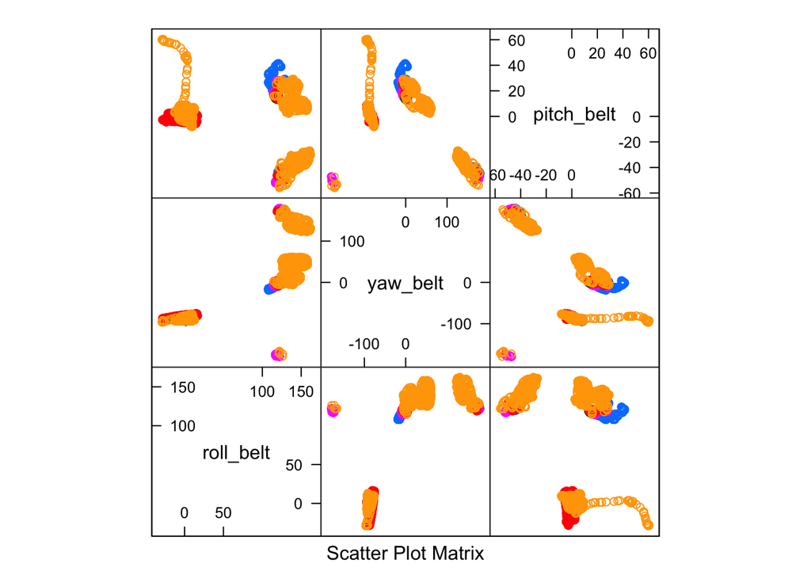

```r
featurePlot(x=trainData[, c("roll_belt", "yaw_belt","pitch_belt")], y=trainData$classe, plot = "pairs" )
```

## Predicting

```r
pred_test <- predict(modFit, newdata = testData)
confusionMatrix(pred_test, testData$classe)
```

```
## Confusion Matrix and Statistics
##
##           Reference
## Prediction    A    B    C    D    E
##          A 1287   45   16   10   13
##          B   26  856   47    3   15
##          C   18   34  769   48    8
##          D   50    7   19  734    7
##          E   14    7    4    9  858
##
## Overall Statistics
##
##                Accuracy : 0.9184
##                  95% CI : (0.9104, 0.9259)
##     No Information Rate : 0.2845
##     P-Value [Acc > NIR] : < 2.2e-16
##
##                   Kappa : 0.8969
##  Mcnemar's Test P-Value : 8.696e-08
##
## Statistics by Class:
##
##                      Class: A Class: B Class: C Class: D Class: E
## Sensitivity            0.9226   0.9020   0.8994   0.9129   0.9523
## Specificity            0.9761   0.9770   0.9733   0.9798   0.9915
## Pos Pred Value         0.9387   0.9039   0.8769   0.8984   0.9619
## Neg Pred Value         0.9694   0.9765   0.9786   0.9829   0.9893
## Prevalence             0.2845   0.1935   0.1743   0.1639   0.1837
## Detection Rate         0.2624   0.1746   0.1568   0.1497   0.1750
## Detection Prevalence   0.2796   0.1931   0.1788   0.1666   0.1819
## Balanced Accuracy      0.9493   0.9395   0.9364   0.9463   0.9719
```

## Validation Set Predictions

```r
result <- predict(modFit, newdata=validation)
as.character(result)
```

```
##  [1] "B" "A" "B" "A" "A" "E" "D" "B" "A" "A" "B" "C" "B" "A" "E" "E" "A"
## [18] "B" "B" "B"
```

## References

1. An Introduction to Statistical Learning, G. James, D. Witten, T. Hastie, R. Tibshirani. Ed. Springer Verlag (2013). ISBN: 978-1-4614-7138-7.
2. The Elements of Statistical Learning (2nd. Edition, 10th printing), T. Hastie, R. Tibshirani, J. Friedman. Ed. Springer Verlag (2009). ISBN: 978-0-3878-4857-0.